# weekend_homework_1

Jonny Nelson

21/01/2022

# Reading in the Data

```r
avocados <- read_csv("data/avocado.csv") %>%
  clean_names()
```

```
## * `` -> ...1
```

```r
knitr::kable(head(avocados))
```

| x1 | date | average_price | total_volume | x4046 | x4225 | x4770 | total_bags | small_bags | large_bags | x_large_bags | type | year | region |
| --- | --- | --- | --- | --- | --- | --- | --- | --- | --- | --- | --- | --- | --- |
| 0 | 2015-12-27 | 1.33 | 64236.62 | 1036.74 | 54454.85 | 48.16 | 8696.87 | 8603.62 | 93.25 | 0 | conventional | 2015 | Albany |
| 1 | 2015-12-20 | 1.35 | 54876.98 | 674.28 | 44638.81 | 58.33 | 9505.56 | 9408.07 | 97.49 | 0 | conventional | 2015 | Albany |
| 2 | 2015-12-13 | 0.93 | 118220.22 | 794.70 | 109149.67 | 130.50 | 8145.35 | 8042.21 | 103.14 | 0 | conventional | 2015 | Albany |
| 3 | 2015-12-06 | 1.08 | 78992.15 | 1132.00 | 71976.41 | 72.58 | 5811.16 | 5677.40 | 133.76 | 0 | conventional | 2015 | Albany |
| 4 | 2015-11-29 | 1.28 | 51039.60 | 941.48 | 43838.39 | 75.78 | 6183.95 | 5986.26 | 197.69 | 0 | conventional | 2015 | Albany |
| 5 | 2015-11-22 | 1.26 | 55979.78 | 1184.27 | 48067.99 | 43.61 | 6683.91 | 6556.47 | 127.44 | 0 | conventional | 2015 | Albany |

# Understanding the Variables

#### index

#### Date: The date of the observation

#### AveragePrice: the average price of a single avocado

#### Total Volume: Total number of avocados sold

#### 4046: Total number of avocados with PLU 4046 sold

#### 4225: Total number of avocados with PLU 4225 sold

#### 4770: Total number of avocados with PLU 4770 sold

#### Total Bags

#### Small Bags

#### Large Bags

#### XLarge Bags

#### type: conventional or organic

#### year: the year

#### region: the city or region of the observation

# Cleaning the data

## Cleaning the Date

#### I wanted to extract out the seasonal variations found in the time series data when plotted against average price

```r
avocados_date <- avocados %>%
  mutate(month = month(date, label = TRUE),
         season = case_when(
         month %in% c("Dec", "Jan", "Feb") ~ "Winter",
         month %in% c("Jun", "Jul", "Aug") ~ "Summer",
         month %in% c("Sep", "Oct", "Nov") ~ "Autumn",
         TRUE ~ "Spring"))

knitr::kable(head(avocados_date %>%
                    select(average_price, date, month, season)))
```

| average_price | date | month | season |
| --- | --- | --- | --- |
| 1.33 | 2015-12-27 | Dec | Winter |
| 1.35 | 2015-12-20 | Dec | Winter |
| 0.93 | 2015-12-13 | Dec | Winter |
| 1.08 | 2015-12-06 | Dec | Winter |
| 1.28 | 2015-11-29 | Nov | Autumn |
| 1.26 | 2015-11-22 | Nov | Autumn |

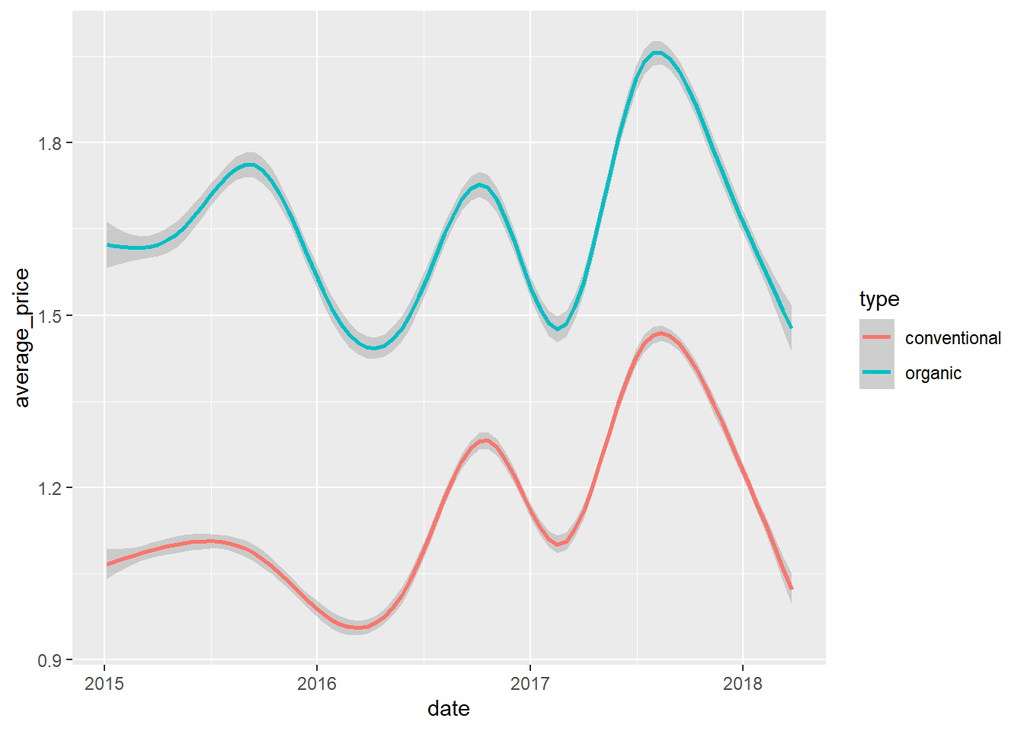

```r
avocados_date %>%
  ggplot() +
  geom_smooth(aes(x = date, y = average_price, colour = type))
```

#### Avocados are a seasonal fruit, so to compress down the amount of information contained in the date, I mutated in the season to find variations

#### The table above just shows how date was mutated to month and then to season.

## Removing Variables

```r
avocados_trim <- avocados_date %>%
  select(-c(x1, date, year, region, month))

knitr::kable(head(avocados_trim))
```

| average_price | total_volume | x4046 | x4225 | x4770 | total_bags | small_bags | large_bags | x_large_bags | type | season |
| --- | --- | --- | --- | --- | --- | --- | --- | --- | --- | --- |
| 1.33 | 64236.62 | 1036.74 | 54454.85 | 48.16 | 8696.87 | 8603.62 | 93.25 | 0 | conventional | Winter |
| 1.35 | 54876.98 | 674.28 | 44638.81 | 58.33 | 9505.56 | 9408.07 | 97.49 | 0 | conventional | Winter |
| 0.93 | 118220.22 | 794.70 | 109149.67 | 130.50 | 8145.35 | 8042.21 | 103.14 | 0 | conventional | Winter |
| 1.08 | 78992.15 | 1132.00 | 71976.41 | 72.58 | 5811.16 | 5677.40 | 133.76 | 0 | conventional | Winter |
| 1.28 | 51039.60 | 941.48 | 43838.39 | 75.78 | 6183.95 | 5986.26 | 197.69 | 0 | conventional | Autumn |
| 1.26 | 55979.78 | 1184.27 | 48067.99 | 43.61 | 6683.91 | 6556.47 | 127.44 | 0 | conventional | Autumn |

#### Next I removed the time series variables, index and region

#### I chose to remove region as it would create too many dummy variables in the when runnning a linear regression model

## Check for Missing Values

```r
summary(avocados_trim)
```

```
##  average_price    total_volume          x4046              x4225
##  Min.   :0.440   Min.   :      85   Min.   :       0   Min.   :       0
##  1st Qu.:1.100   1st Qu.:   10839   1st Qu.:     854   1st Qu.:    3009
##  Median :1.370   Median :  107377   Median :    8645   Median :   29061
##  Mean   :1.406   Mean   :  850644   Mean   :  293008   Mean   :  295155
##  3rd Qu.:1.660   3rd Qu.:  432962   3rd Qu.:  111020   3rd Qu.:  150207
##  Max.   :3.250   Max.   :62505647   Max.   :22743616   Max.   :20470573
##      x4770           total_bags         small_bags         large_bags
##  Min.   :      0   Min.   :       0   Min.   :       0   Min.   :      0
##  1st Qu.:      0   1st Qu.:    5089   1st Qu.:    2849   1st Qu.:    127
##  Median :    185   Median :   39744   Median :   26363   Median :   2648
##  Mean   :  22840   Mean   :  239639   Mean   :  182195   Mean   :  54338
##  3rd Qu.:   6243   3rd Qu.:  110783   3rd Qu.:   83338   3rd Qu.:  22029
##  Max.   :2546439   Max.   :19373134   Max.   :13384587   Max.   :5719097
##   x_large_bags          type              season
##  Min.   :     0.0   Length:18249       Length:18249
##  1st Qu.:     0.0   Class :character   Class :character
##  Median :     0.0   Mode  :character   Mode  :character
##  Mean   :  3106.4
##  3rd Qu.:   132.5
##  Max.   :551693.7
```

#### *Whoop Whoop! No missing values here*

# Using ggpairs to find Correlation to Average Price

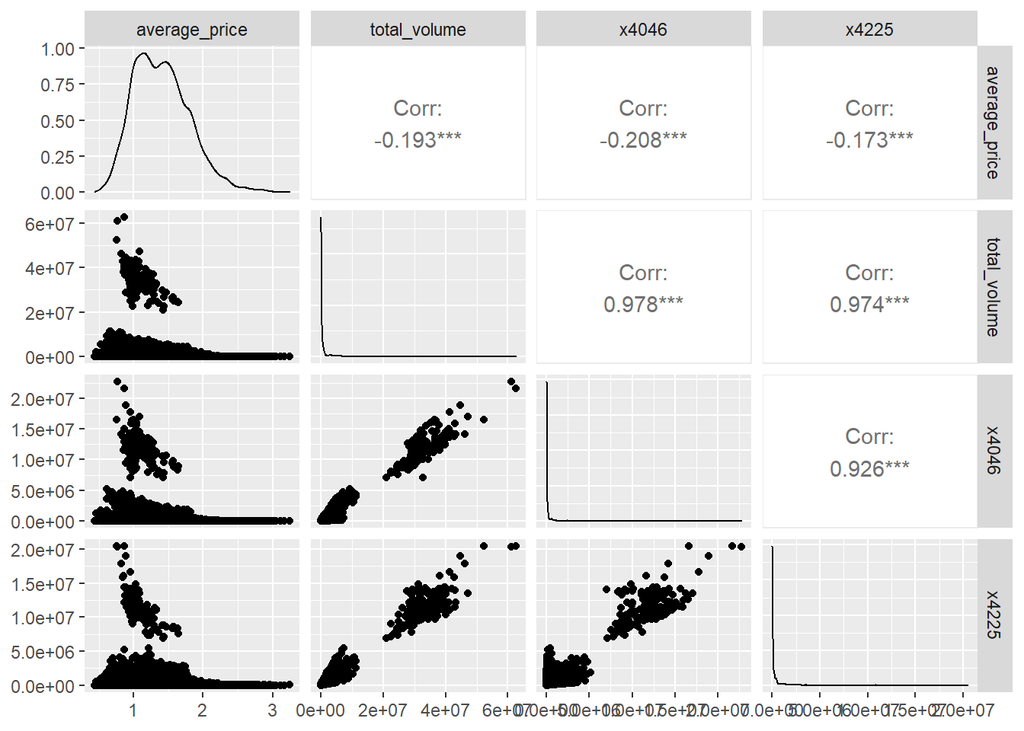

```r
avocados_trim %>%
  ggpairs(aes(), columns = 1:4)
```

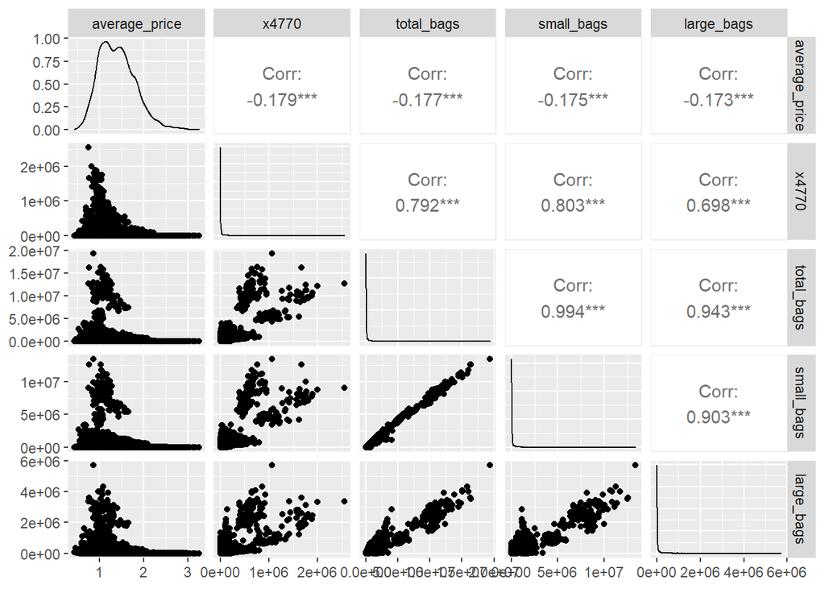

```r
avocados_trim %>%
  ggpairs(aes(), columns = c(1,5:8))
```

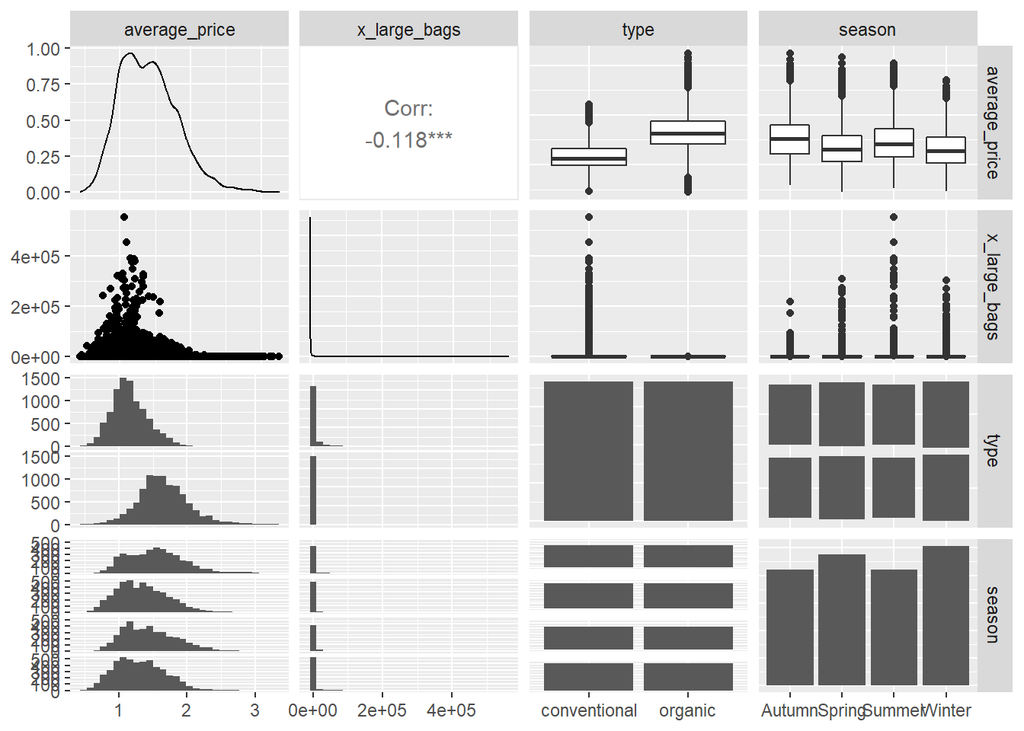

```r
avocados_trim %>%
  ggpairs(aes(), columns = c(1,9:11))
```

#### From the correlational plots we can see that type and then season are the most highly correlated with the average price

```r
# Looking at ggcorr() here


# avocados_trim_01 <- avocados_trim %>%
#   dplyr::select(1:6)
#
# avocados_trim_02 <- avocados_trim %>%
#   dplyr::select(1, 7:11)
#
# ggcorr(data  = avocados_trim_02,
#        label = TRUE,
#        label_size = 5) +
#   ggtitle("Correlation Plot for Penguins by Species")
```

## Taking a closer look at the season (and month)

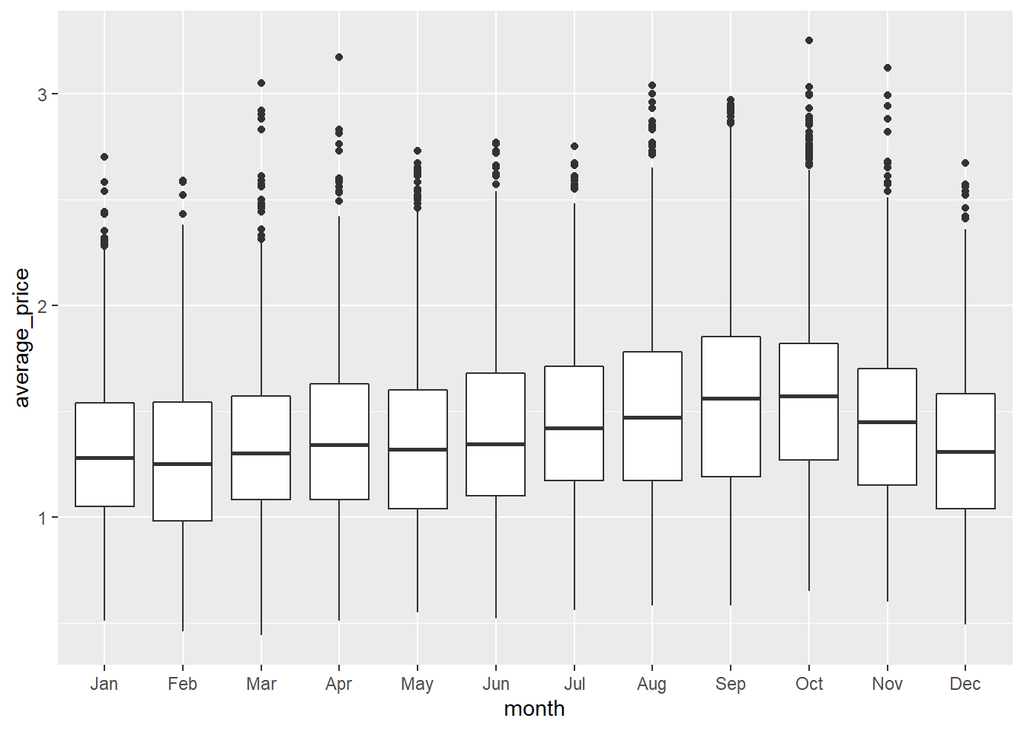

```r
avocados_date %>%
  ggplot() +
  geom_boxplot(aes(x = month, y = average_price))
```

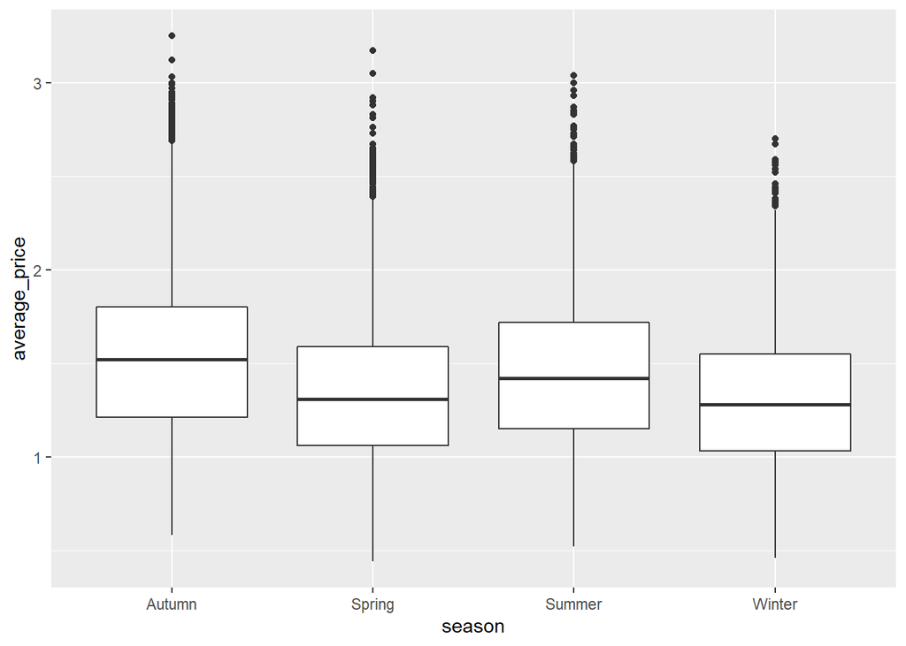

```r
avocados_date %>%
  ggplot() +
  geom_boxplot(aes(x = season, y = average_price))
```

* #### We can see from the month data that there are definite seasonal fluctuations.

#### To bring some context to these plots, we have found that most avocados imported into the U.S come from Mexico, while some are grown domestically in regions like california. See plot below.

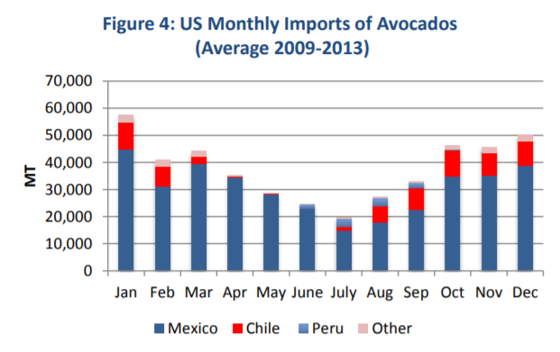

#### _source - https://pdf.usaid.gov/pdf_docs/PA00KP28.pdf_

#### The growing season for the avocados in Mexico and the U.S. are are shown below.

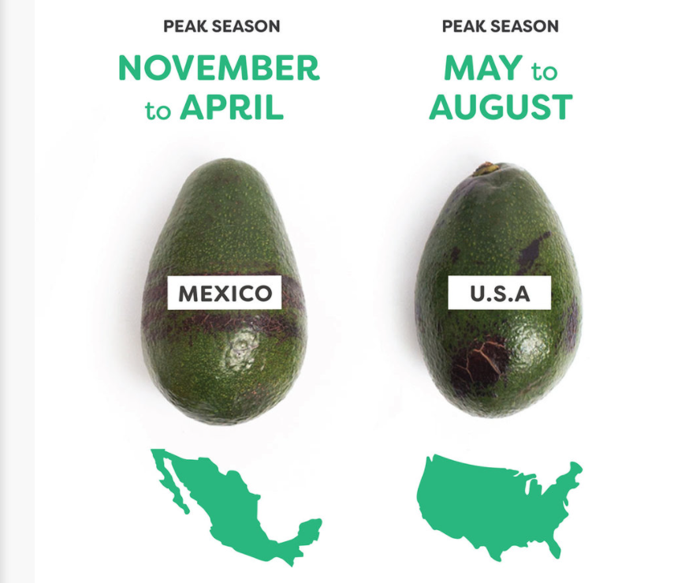

#### _source - http://blog.imperfectfoods.com/blog-1/2019/2/13/when-are-avocados-in-season_

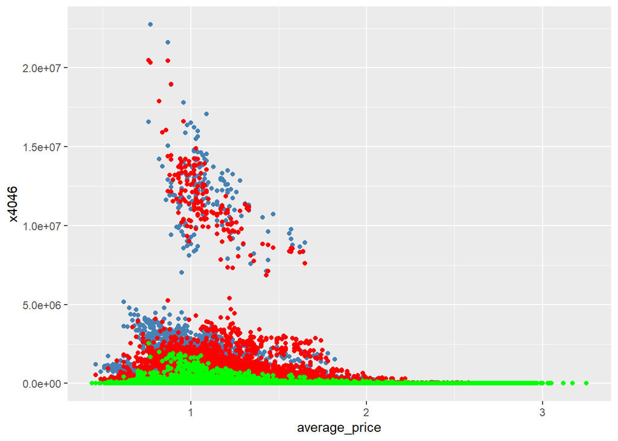

```r
avocados %>%
  ggplot() +
  geom_point(aes(x = average_price, y = x4046), colour = "steel blue") +
  geom_point(aes(x = average_price, y = x4225), colour = "red") +
  geom_point(aes(x = average_price, y = x4770), colour = "green")
```

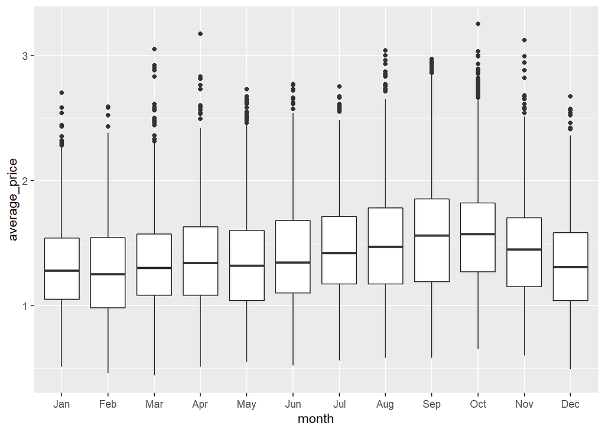

```r
# x4046 - non-organic small/medium Hass Avocados
# x4225 - non-organic large Hass Avocados
# x4770 - non-organic extra large Hass Avocados

# Mutating useful information out of the date variable

# We know avocados are seasonal, so is there a supply demand dynamic at all to be obersved?

# mutate to month and season?

avocados_date %>%
  ggplot() +
  geom_boxplot(aes(x = month, y = average_price))
```

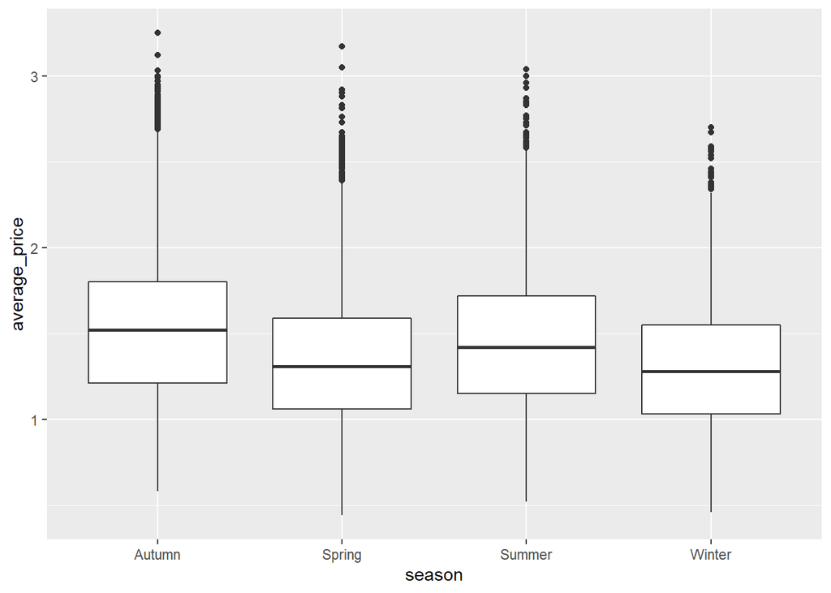

```r
avocados_date %>%
  ggplot() +
  geom_boxplot(aes(x = season, y = average_price))
```

```r
# uptick in the price around the autumn months

# mutate in a season variable we see the different in the seasons while reducing the number of variables

# Mexico is the largest avocado exporter by an order of magnitude. It is likely that all americas avocados are coming from there. Harvesting begins in early spring spring

# Image

# source - http://blog.imperfectfoods.com/blog-1/2019/2/13/when-are-avocados-in-season

# Regions

unique(avocados$region)
```

```
##  [1] "Albany"              "Atlanta"             "BaltimoreWashington"
##  [4] "Boise"               "Boston"              "BuffaloRochester"
##  [7] "California"          "Charlotte"           "Chicago"
## [10] "CincinnatiDayton"    "Columbus"            "DallasFtWorth"
## [13] "Denver"              "Detroit"             "GrandRapids"
## [16] "GreatLakes"          "HarrisburgScranton"  "HartfordSpringfield"
## [19] "Houston"             "Indianapolis"        "Jacksonville"
## [22] "LasVegas"            "LosAngeles"          "Louisville"
## [25] "MiamiFtLauderdale"   "Midsouth"            "Nashville"
## [28] "NewOrleansMobile"    "NewYork"             "Northeast"
## [31] "NorthernNewEngland"  "Orlando"             "Philadelphia"
## [34] "PhoenixTucson"       "Pittsburgh"          "Plains"
## [37] "Portland"            "RaleighGreensboro"   "RichmondNorfolk"
## [40] "Roanoke"             "Sacramento"          "SanDiego"
## [43] "SanFrancisco"        "Seattle"             "SouthCarolina"
## [46] "SouthCentral"        "Southeast"           "Spokane"
## [49] "StLouis"             "Syracuse"            "Tampa"
## [52] "TotalUS"             "West"                "WestTexNewMexico"
```

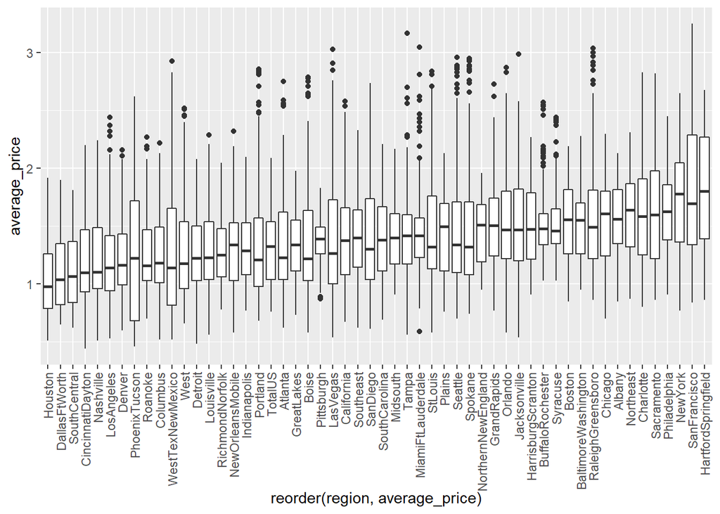

```r
avocados %>%
  ggplot() +
  geom_boxplot(aes(y = average_price, x = reorder(region, average_price))) +
  theme(axis.text.x = element_text(angle = 90, vjust = 0.5, hjust=1))
```

```r
# Definite correlation between region and price but the number of dummy variables needed to be included would be ridiculous.


summary(avocados)
```

```
##        x1             date            average_price    total_volume
##  Min.   : 0.00   Min.   :2015-01-04   Min.   :0.440   Min.   :      85
##  1st Qu.:10.00   1st Qu.:2015-10-25   1st Qu.:1.100   1st Qu.:   10839
##  Median :24.00   Median :2016-08-14   Median :1.370   Median :  107377
##  Mean   :24.23   Mean   :2016-08-13   Mean   :1.406   Mean   :  850644
##  3rd Qu.:38.00   3rd Qu.:2017-06-04   3rd Qu.:1.660   3rd Qu.:  432962
##  Max.   :52.00   Max.   :2018-03-25   Max.   :3.250   Max.   :62505647
##      x4046              x4225              x4770           total_bags
##  Min.   :       0   Min.   :       0   Min.   :      0   Min.   :       0
##  1st Qu.:     854   1st Qu.:    3009   1st Qu.:      0   1st Qu.:    5089
##  Median :    8645   Median :   29061   Median :    185   Median :   39744
##  Mean   :  293008   Mean   :  295155   Mean   :  22840   Mean   :  239639
##  3rd Qu.:  111020   3rd Qu.:  150207   3rd Qu.:   6243   3rd Qu.:  110783
##  Max.   :22743616   Max.   :20470573   Max.   :2546439   Max.   :19373134
##    small_bags         large_bags       x_large_bags          type
##  Min.   :       0   Min.   :      0   Min.   :     0.0   Length:18249
##  1st Qu.:    2849   1st Qu.:    127   1st Qu.:     0.0   Class :character
##  Median :   26363   Median :   2648   Median :     0.0   Mode  :character
##  Mean   :  182195   Mean   :  54338   Mean   :  3106.4
##  3rd Qu.:   83338   3rd Qu.:  22029   3rd Qu.:   132.5
##  Max.   :13384587   Max.   :5719097   Max.   :551693.7
##       year         region
##  Min.   :2015   Length:18249
##  1st Qu.:2015   Class :character
##  Median :2016   Mode  :character
##  Mean   :2016
##  3rd Qu.:2017
##  Max.   :2018
```

```r
# No NA'S Whoop Whoop

# Type

unique(avocados$type)
```

```
## [1] "conventional" "organic"
```

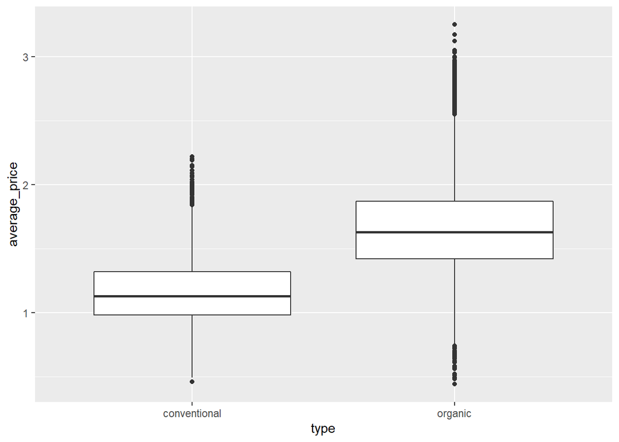

```r
avocados %>%
  ggplot() +
  geom_boxplot(aes(x = type, y = average_price))
```

```r
avocados_trim <- avocados_date %>%
  select(-c(x1, date, year, region, month))
```

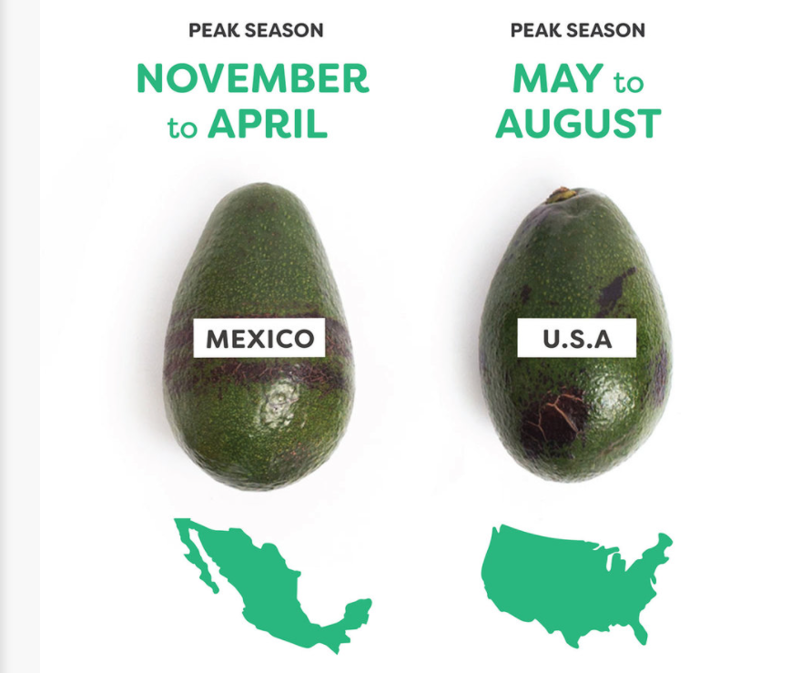

# Understanding the variables

#### index

#### Date: The date of the observation

#### AveragePrice: the average price of a single avocado

#### Total Volume: Total number of avocados sold

#### 4046: Total number of avocados with PLU 4046 sold

#### 4225: Total number of avocados with PLU 4225 sold

#### 4770: Total number of avocados with PLU 4770 sold

#### Total Bags

#### Small Bags

#### Large Bags

#### XLarge Bags

#### type: conventional or organic

#### year: the year

#### region: the city or region of the observation

## Variables to remove

#### index, date, year will all not be indicative of the price of avocados

#### May have to reinclude the date - split by month - may be indicative of average price due to supply demand dynamics

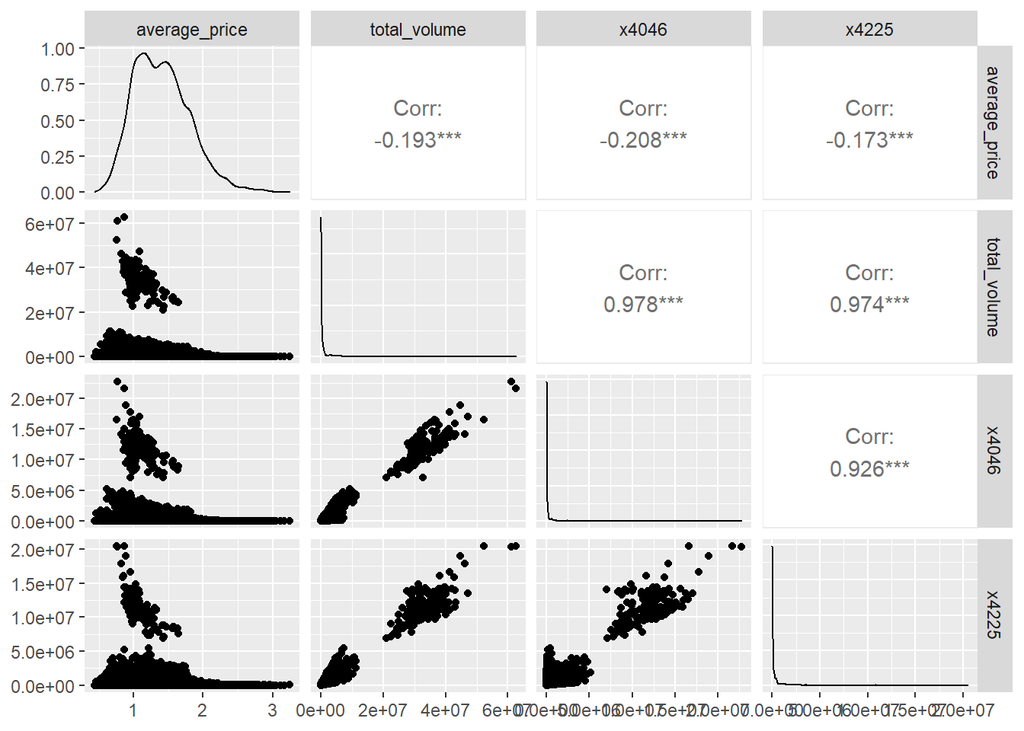

```r
avocados_trim %>%
  ggpairs(aes(), columns = 1:4)
```

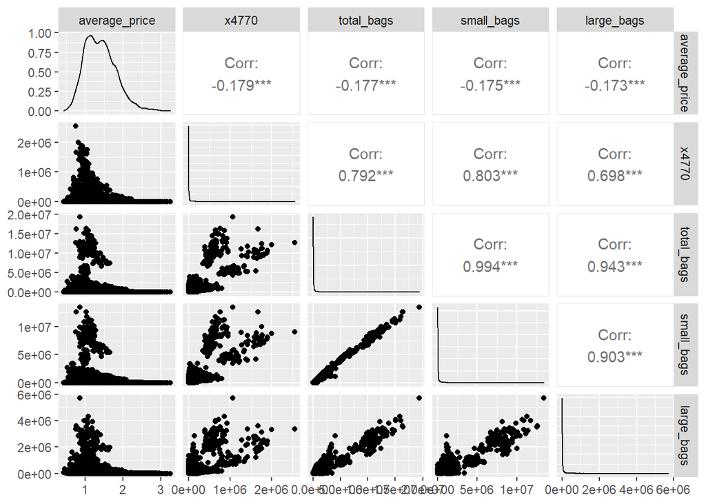

```r
avocados_trim %>%
  ggpairs(aes(), columns = c(1,5:8))
```

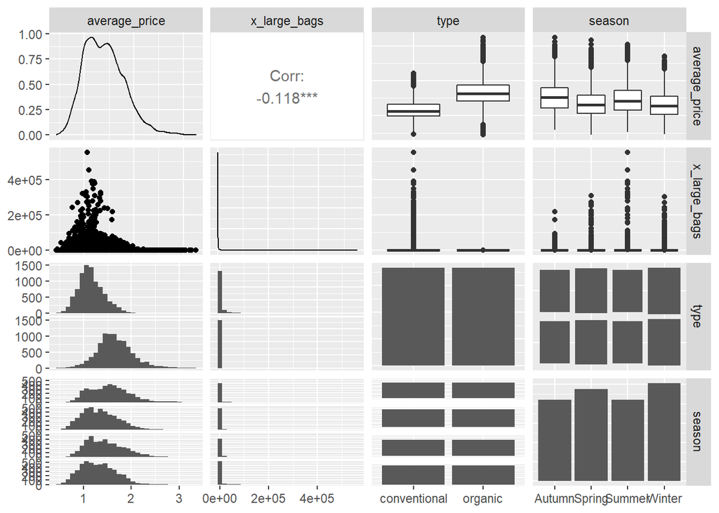

```r
avocados_trim %>%
  ggpairs(aes(), columns = c(1,9:11))
```

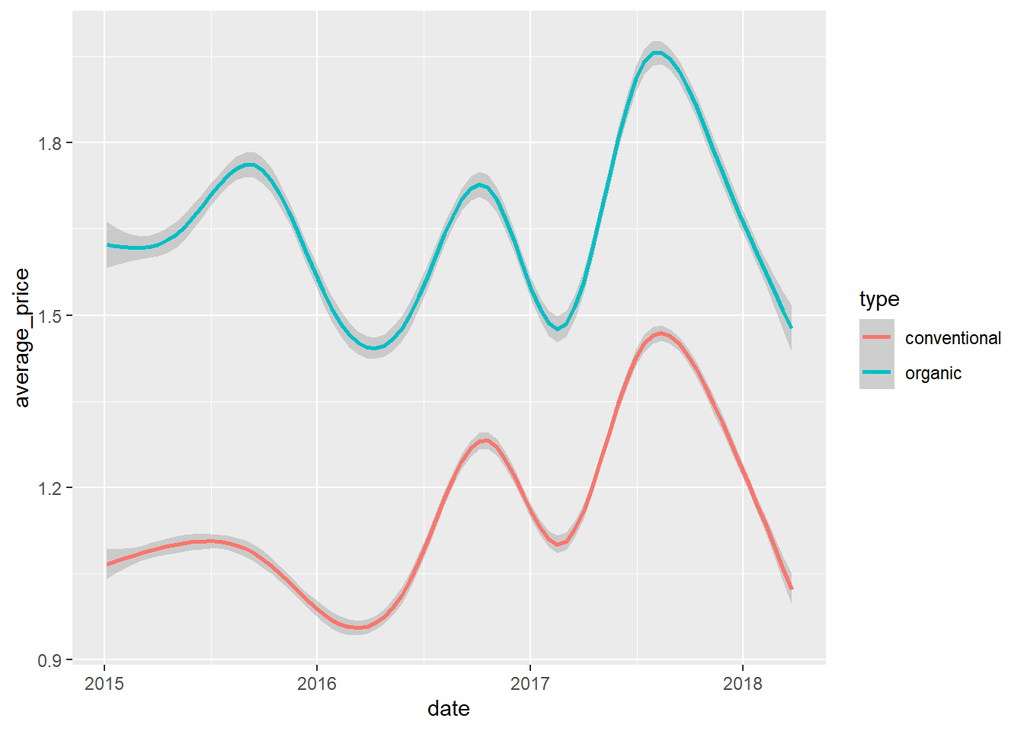

```r
# type looks most correlated

avocados_date %>%
  ggplot() +
  geom_smooth(aes(x = date, y = average_price, colour = type))
```